# Základy vizualizace dat a práce s grafy v R

Zpracovávání výzkumných dat pomocí jazyka R

## Program

- opakování z minulé hodiny
- kontrola domácího úkolu
- kdy a proč vizualizace
- typy dat
- vizualizace v R
- vizualizace v `ggplot2`
- kde hledat

## Kontrola domácí práce

### Úloha 1

**Byla naměřena následující koncentrace látky:**

```r
koncentrace <- c("vzorek1" = "75 mg/l",
                 "vzorek2" = "101 mg/l",
                 "vzorek3" = "158 mg/l",
                 "vzorek4" = "48 mg/l")
```

- Pokud je koncentrace vyšší než 100 mg/l, vypište „Vysoká koncentrace“.
- Pokud je koncentrace mezi 50 a 100 mg/l včetně, vypište „Normální koncentrace“.
- Jinak vypište „Nízká koncentrace“.
1. Vytvoříme si vektor s pouze číselními hodnotami.

   ```r
   hodnoty <- parse_number(koncentrace); hodnoty
   ```

   ```
   [1]  75 101 158  48
   ```

2. Přepišme si jednotlivé hodnoty pomocí zadaného klíče.

   ```r
   #ifelse
   ifelse(hodnoty > 100, "Vysoká koncentrace",
          ifelse(hodnoty >= 50, "Normální koncentrace","Nízká koncentrace"))
   ```

   ```
   [1] "Normální koncentrace" "Vysoká koncentrace"   "Vysoká koncentrace"
   [4] "Nízká koncentrace"
   ```

   ```r
   #case_when
   hodnoty <- case_when(
     hodnoty < 50 ~ "Nizka koncentrace",
     hodnoty < 100 ~ "Normalni koncentrace",
     hodnoty > 100 ~ "Vysoka koncentrace"); hodnoty
   ```

   ```
   [1] "Normalni koncentrace" "Vysoka koncentrace"   "Vysoka koncentrace"
   [4] "Nizka koncentrace"
   ```

3. Můžeme si pro snadnější porozumnění přidat názvy jednotlivých hodnot.

   ```r
   names(hodnoty) <- names(koncentrace)
   hodnoty
   ```

### Úloha 2

**V laboratorní kultuře je na začátku 200 bakterií. Počet bakterií se každou hodinu zvýší o 30 %. Kolik jich bude po osmi hodinách?**

1. Vytvořme si základní hodnotu.

   ```r
   bakterie <- 200
   ```

2. Projeďme si množství bakterií v osmi cyklech a zobrazme si výslednou hodnotu.

   ```r
   for (hodina in 1:8) {
     bakterie <- bakterie * 1.3
   }

   floor(bakterie) #muzeme mit necely pocet bakterii?
   ```

   ```
   [1] 1631
   ```

### Úloha 3

**Během pokusu jsme čtyři vzorky vystavily třem látkám a změřili jejich reaktivitu.**

```r
mereni <- matrix(
  c(12, 15, 18, 20, 25, 30,
  8,  10, 12, 35, 40, 45),
  nrow = 4, byrow = TRUE)

rownames(mereni) <- c("Vzorek 1", "Vzorek 2",
                      "Vzorek 3", "Vzorek 4")
colnames(mereni) <- c("Latka A", "Latka B", "Latka C")
```

- Jaká je průměrná reaktivita každého vzorku?
- Jaké byly nejvyšší hodnoty způsobené reaktivity pro každou látku a která látka způsobila největší reaktivitu?
1. Spočítáme si průměrnou reaktivitu každého vzorku.

   ```r
   apply(mereni, 1, mean)
   ```

   ```
   Vzorek 1 Vzorek 2 Vzorek 3 Vzorek 4
         15       25       10       40
   ```

   ```r
   maxima <- apply(mereni, 2, max); maxima
   ```

   ```
   Latka A Latka B Latka C
        35      40      45
   ```

   ```r
   max(maxima)
   ```

   ```
   [1] 45
   ```

   ```r
   which.max(maxima) #pokud chceme zjistit nazev a pozici
   ```

   ```
   Latka C
         3
   ```

   ```r
   names(which.max(maxima)) #a pokud si ji chceme i vypsat
   ```

   ```
   [1] "Latka C"
   ```

### Úloha 4

**U pacientů byly naměřeny následující hodnoty glukózy v krvi (mmol/l):**

```r
c(8.5, 3.9, 5.9, 4.0, 4.5, 9.0, 6.3, 5.1, 7.0, 4.8, 7.2, 4.2)
```

```
 [1] 8.5 3.9 5.9 4.0 4.5 9.0 6.3 5.1 7.0 4.8 7.2 4.2
```

**Množství cukru v krvi se dělí dle následující tabulky:**

| Stav | Hodnoty |
| --- | --- |
| Norma nalačno | 3.9 - 5.5 |
| Prediabetes | 5.6 - 6.9 |
| Cukrovka | ≥ 7.0 |

**Vytvořte přehlednou tabulku, kdy pro každého pacienta napíšete jejich ID dle pořadí, jejich naměřenou hodnotu a stav podle tabulky.**

1. Pro snadnější práci si hodnoty uložíme do pojmenované proměnné.

```r
glukoza <- c(8.5, 3.9, 5.9, 4.0, 4.5, 9.0, 6.3, 5.1, 7.0, 4.8, 7.2, 4.2)
```

2. Následně si vytvoříme nový data frame `pacienti`, kdy pro tvorbu jednotlivých sloupců použijeme hodnoty z `glukoza` a tabulky kategorizace.

```r
  pacienti <- data.frame(
    ID = 1:length(glukoza),
    Hodnota = glukoza,
    Stav = case_when(
      glukoza >= 3.9 & glukoza < 5.6 ~ "Norma nalačno",
      glukoza >= 5.6 & glukoza < 7 ~ "Prediabetes",
      glukoza >= 7.0 ~ "Cukrovka",
      .default = "Mimo běžné rozmezí")); pacienti
```

```
   ID Hodnota          Stav
1   1     8.5      Cukrovka
2   2     3.9 Norma nalačno
3   3     5.9   Prediabetes
4   4     4.0 Norma nalačno
5   5     4.5 Norma nalačno
6   6     9.0      Cukrovka
7   7     6.3   Prediabetes
8   8     5.1 Norma nalačno
9   9     7.0      Cukrovka
10 10     4.8 Norma nalačno
11 11     7.2      Cukrovka
12 12     4.2 Norma nalačno
```

## K čemu slouží vizualizace

1. Předávání informací o datech
2. Vizuální kontrola dat

**Vizualizace není pouze finální výsledek**

Vizualizace je pouhé zobrazení dat - **je dobré ji využívat i v průběhu samotné datové analýzy**.

Co když chceme například rychle zjistit hrubou korelaci mezi `Sepal.Length` a `Sepal.Width` u datasetu `iris`? Dle naší hypotézy nezávisí na odrůdě.

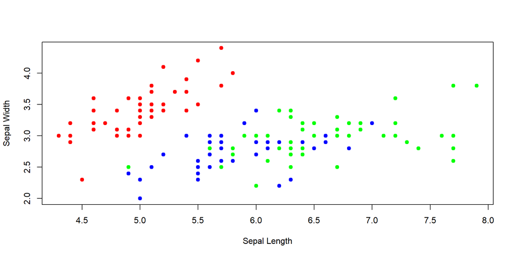

```r
colors <- c("red", "blue", "green")

plot(iris$Sepal.Length,
     iris$Sepal.Width,
     col = colors[iris$Species], #nezapomente faktory jsou ulozeny jako cisla,
     pch = 19,
     xlab = "Sepal Length",
     ylab = "Sepal Width")
```

### Proč je potřeba znát s jakými daty pracujeme?

Načtěme si dataset, který si chceme vizualizovat.

V tomto případě pracujeme s datasetem `newborns`, který v sobě zahrnuje informace o skupině novorozenců; jejich pohlaví (`sex.C`), váhu v gramech (`weight.C`), počet starších sourozenců (`prch.N`) a úroveň vzdělání jejich matky při porodu (`edu.M`).

S datasetem budeme pracovat dále během procvičení a samostatných cvičení - **je důležité, abyste si následující kód nahráli do R**.

```r
dataNewborns <- read.delim("newborns.txt")
str(dataNewborns)
```

```
'data.frame':   1402 obs. of  4 variables:
 $ edu.M   : int  2 2 2 1 3 2 1 2 2 1 ...
 $ prch.N  : int  0 0 0 0 0 1 2 0 0 0 ...
 $ sex.C   : chr  "m" "m" "f" "m" ...
 $ weight.C: int  3470 3240 2980 3280 3030 3650 4080 3040 3070 3110 ...
```

```r
sum(is.na(dataNewborns)) #mame nejake chybejici hodnoty?
```

```
[1] 24
```

```r
dataNewborns <- na.omit(dataNewborns)

dataNewborns$sex.C <- as.factor(dataNewborns$sex.C)
dataNewborns$edu.M <- factor(dataNewborns$edu.M,
                             labels = c("ZS", "SS", "SSm", "VS"))
#copak znamena tato funkce a argument labels?
str(dataNewborns)
```

```
'data.frame':   1381 obs. of  4 variables:
 $ edu.M   : Factor w/ 4 levels "ZS","SS","SSm",..: 2 2 2 1 3 2 1 2 2 1 ...
 $ prch.N  : int  0 0 0 0 0 1 2 0 0 0 ...
 $ sex.C   : Factor w/ 2 levels "f","m": 2 2 1 2 2 2 1 1 1 2 ...
 $ weight.C: int  3470 3240 2980 3280 3030 3650 4080 3040 3070 3110 ...
 - attr(*, "na.action")= 'omit' Named int [1:21] 53 54 256 297 476 482 682 708 760 857 ...
  ..- attr(*, "names")= chr [1:21] "53" "54" "256" "297" ...
```

Vytvoříme graf, který nám ukáže **váha novorozenců podle počtu starších sourozenců**.

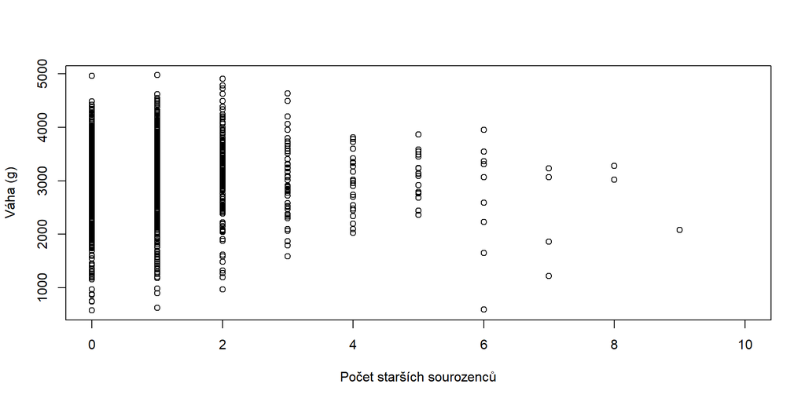

```r
plot(
  dataNewborns$prch.N,
  dataNewborns$weight.C,
  xlim = c(0,10),
  ylab = "Váha (g)",
  xlab = "Počet starších sourozenců")
```

**No… to nevypadá úplně nejlíp. Opravdu bychom měli používat bodový graf?**

**Volba grafu je závislá na typu dat**

Není možné používat grafy náhodně - **specifické typy grafů jsou určené pro vizualizaci různých typů dat**. (A u analýz je tato informace důležitá dvojnásob.)

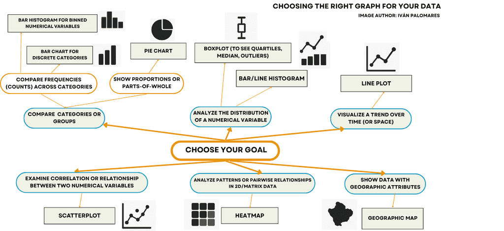

## Typy dat

### Kategoriální (kvalitativní) data

> Data, která vyjadřují určitou vlastnost nebo charakteristiku; jinými slovy data, která lze rozdělit do kategorií.
- **Nominální data**
  - data, která lze rozdělit do kategorií, mezi nimiž však neexistuje žádné přirozené pořadí
  - krevní skupina, barva očí, typ barvení buněk daného vzorku
- **Ordinální data**
  - data, která lze rozdělit do kategorií a zároveň je lze seřadit podle určitého pořadí
    - jednu kategorii lze tedy zařadit výše nebo níže než jinou
  - novorozenec, batole, dítě, dospívající, dospělý, senior
  - první, druhý, třetí - 1, 2, 3

### Numerická (kvantitativní) data

> Data, která lze kvantifikovat a měřit
- **Intervalová data**
  - data, která lze vyjádřit jako hodnoty lišící se o určitý interval
    - stručně řečeno: běžné číselné hodnoty od minus nekonečna do plus nekonečna
  - stupně Celsia, nadmořská výška
- **Poměrová data (ratio)**
  - data, která lze vyjádřit jako hodnoty lišící se o určitý interval a která mají **definovanou nulovou hodnotu**, která umožňuje porovnávat velikosti pomocí poměrů
    - příkladem je hmotnost – něco nemůže mít přesně zápornou hmotnost v gramech
      - objekt X váží 20 gramů, objekt Y váží 40 gramů, objekt Y je tedy dvakrát těžší než objekt X
  - délka kosti, počet odebraných vzorků

**Je možné změnit datový typ?**

Ano, například převedením intervalových nebo poměrových dat na ordinální data - výšku v centimetrech můžeme rozdělit do kategorií podle výškových rozdílů po 5 cm.

**Jakmile víte, s jakým typem dat pracujete, můžete je upravovat pro potřeby vizualizace a hlavně vybírat vhodný typ grafu.**

## Vizualizace v R a RStudiu<sup>1</sup>

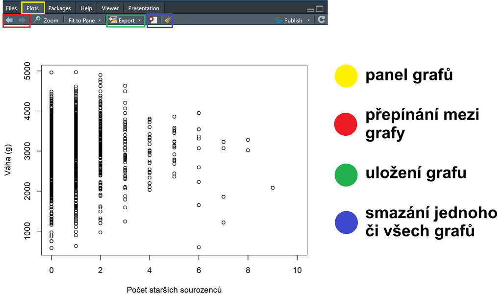

[^1]: Upozornění: v některých případech (a při specifickém nastavení) se grafy mohou zobrazovat v **externím okně**.

## `baseR` grafy

**R má pro spoustu grafů svoji vlastní funkci**. Před tím, než si je ovšem ukážeme, tak se naučíme argumenty, které mají společné - například určení barev, tloušťku čar, či ohraničení.

Spousta těchto argumentů je podobná i argumentům grafů vytvořených pomocí balíčku `ggplot`, jak si ukážeme později.

**Proč nezačínat rovnou s `ggplot`?**

Během této a následujících hodin budeme používat především balíček `ggplot`. Ten umožňuje vytváření grafů s obrovským množstvím svobody, pro **rychlou vizualizaci je ovšem poněkud zdlouhavý**, a jeho specifický syntax může být pro začátečníka s vizualizací složitý. Sám navíc přebírá určité principy z base R.

## Základní argumenty vizualizace v R

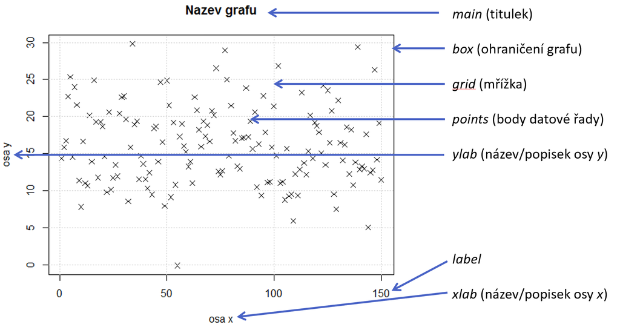

### Mapování dat pomocí funkce `plot`

Nejrychlejším způsobem, jak v R vytvořit graf, je pomocí fuknce `plot`.

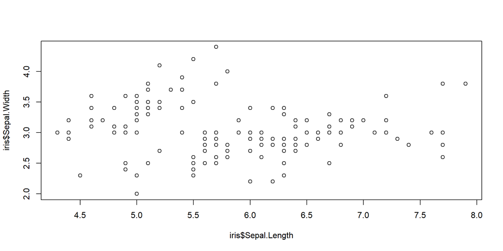

```r
plot(
  x = iris$Sepal.Length, #osa x
  y = iris$Sepal.Width) #osa y
```

Můžete se také setkat s následujícím **zápisem závislosti**:

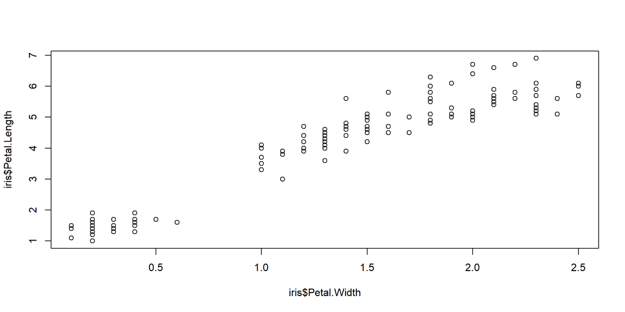

```r
plot(iris$Petal.Length ~ iris$Petal.Width)
```

A to je všechno? Co když si chceme udělat graf přesně dle našeho přání?

### Ukázka grafu s nejčastěji používanými argumenty funkce `plot`

```r
#VYTVORENI GRAFU
plot(
  x = iris$Sepal.Length, #data pro osu x
  y = iris$Sepal.Width, #data pro osu y
  type = "p", #typ grafu - point

  #Body
  pch = 19, #typ bodu
  cex = 1.2, #velikost bodu
  col = "darkblue", #barva bodu

  #Popisky os
  xlab = "Sepal length",
  ylab = "Sepal width",

  #Nadpis
  main = "Relationship between sepal length and width",

  #Rozsah os
  xlim = c(min(iris$Sepal.Length), max(iris$Sepal.Length)),
  ylim = c(1.7, 4.8),

  #Barva os a popisku
  col.axis = "red", #barva hodnot os
  col.lab = "darkgreen", #barva popisku os
  col.main = "darkblue", #barva nadpisu

  #Velikost a vzhled textu
  cex.main = 1.4, #velikost nadpisu (standard 1)
  font.main = 2, #styl nadpisu (2 = bold)
  cex.lab = 0.8, #velikost popisku
  font.lab = 3, #styl popisku (3 = italic)
  lwd = 1.5) #tloustka linii (lwd je casty argument u doprovodnych car)

#PRIDANI LEGENDY
legend(
  "topright",
  legend = "specimen ID",
  col = "darkblue", #barva bodu
  pch = 19, #tvar bodu
  pt.cex = 1.2, #velikost bodu
  cex = 0.9, #tloustka boxu
  title = "Legend")

#PRIDANI POPISKU jednotlivych bodu
text(
  iris$Sepal.Length, #urceni pozice bodu na ose x
  iris$Sepal.Width, #urceni pozice bodu na ose y
  labels = rownames(iris), #co ma byt popisek
  pos = 3, #pozice
  cex = 0.7) #velikost
```

**Jaký je výsledek tohoto kódu?**

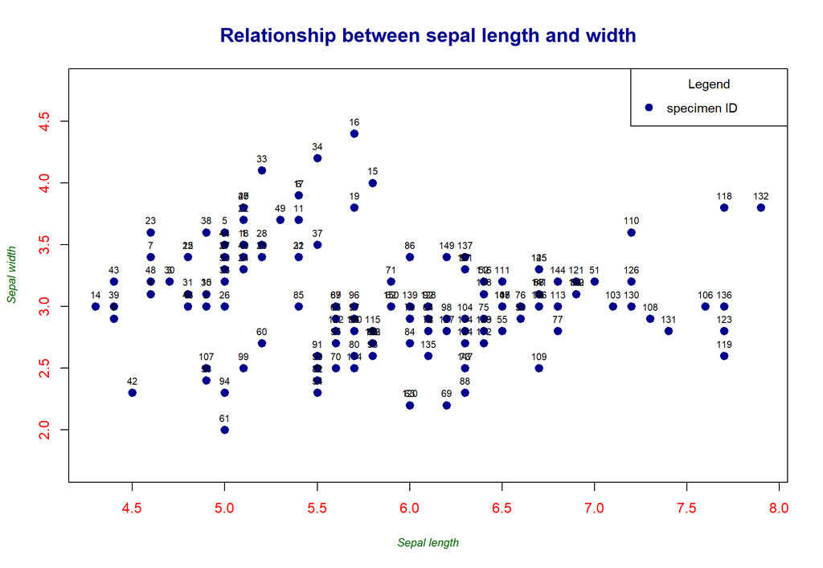

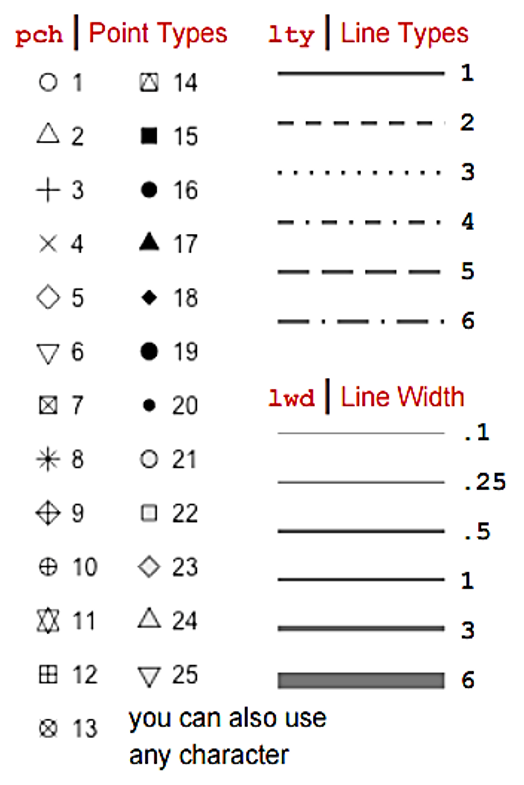

Autor: Gaston Sanchez

## Procvičení

1. Máme dataset `women`, který obsahuje výšku žen v palcích a jejich váhu v librách (ano jedná se o americký dataset).

```r
head(women)
```

```
  height weight
1     58    115
2     59    117
3     60    120
4     61    123
5     62    126
6     63    129
```

**Existuje vztah mezi tělesnou váhou a výškou?**

2. Máme dataset `mtcars`, který v sobě obsahuje rozličné informace o jednotlivých značkách a typech aut.

Zajímá nás sloupec `mpg` aneb miles per gallon a `wt` aneb weight.

```r
head(mtcars)
```

```
                   mpg cyl disp  hp drat    wt  qsec vs am gear carb
Mazda RX4         21.0   6  160 110 3.90 2.620 16.46  0  1    4    4
Mazda RX4 Wag     21.0   6  160 110 3.90 2.875 17.02  0  1    4    4
Datsun 710        22.8   4  108  93 3.85 2.320 18.61  1  1    4    1
Hornet 4 Drive    21.4   6  258 110 3.08 3.215 19.44  1  0    3    1
Hornet Sportabout 18.7   8  360 175 3.15 3.440 17.02  0  0    3    2
Valiant           18.1   6  225 105 2.76 3.460 20.22  1  0    3    1
```

Chceme si zjistit, jestli **je nějaký vztah mezi tím, jak je auto těžké, a jakou má spotřebu pohonných hmot na míli**.

## Samostatné cvičení

Máme dataset `trees`, který v sobě obsahuje informace o měření obvodu stromů v palcích (`Girth`) a jejich výšky ve stopách (`Height`).

Zkuste zjistit, jestli by **mezi sebou tyto proměnné mohly mít nějaký vztah**.

## Řešení

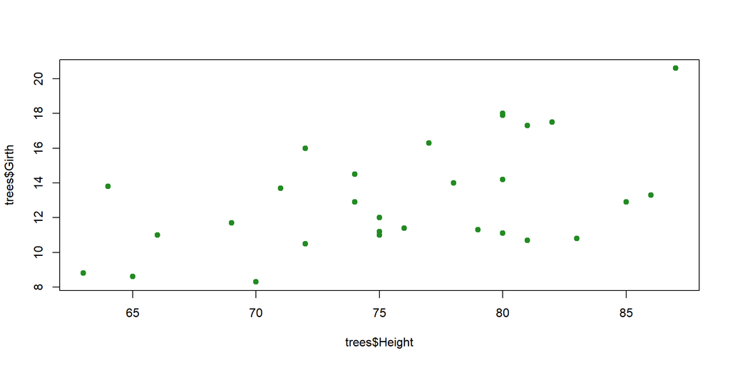

```r
plot(
  trees$Girth ~ trees$Height,
  type = "p",
  pch = 19,
  col = "forestgreen")
```

Co když ale chceme komplikovanější grafy? Jak jsme navíc viděli na začátku, ne každou informaci lze přehledně vyjádřit jednoduchým bodovým grafem.

**Jaký graf vybereme pro jaký typ vizualizace?**

Na následujícím snímku máte stručný tahák toho, kdy se jaký typ grafu používá v závislosti na zkoumaných datech.

Během dnešní hodiny si probereme základní typy: sloupcové, bodové a čárové grafy.

Budeme si ukazovat jejich provedení jak v baseR, tak pomocí balíčku `ggplot`.

### Cheatsheet volby grafu

| Co chci zjistit? | Jaký graf použít? |
| --- | --- |
| Porovnání kategorií (skupin) | Bar plot, boxplot |
| Rozložení numerických hodnot | Histogram, density plot, violin plot |
| Vztah dvou numerických proměnných | Scatter plot |
| Změny v čase | Line chart |
| Podíly kategorií | Pie chart, stacked bar plot |
| Odlehlé hodnoty | Boxplot, scatter plot |

## Barplot

> graf určený k vizualizaci vztahu a hodnot kategoriálních dat

Novorozenci podle úrovně dosaženého vzdělání matky `edu.M`.

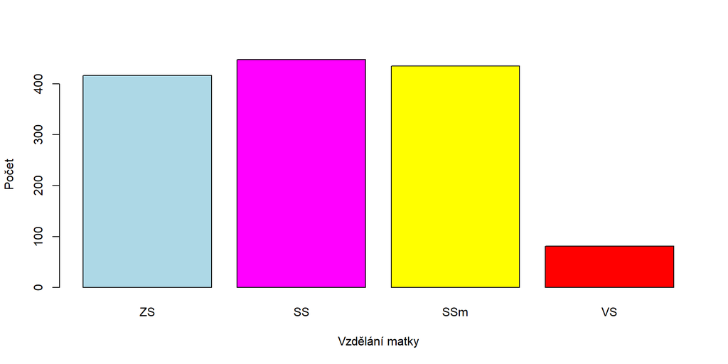

```r
barplot(table(dataNewborns$edu.M),
  xlab = "Vzdělání matky",
  ylab = "Počet",
  col = c("lightblue", "magenta", "yellow", "red"))
```

### Co je funkce table?

Pro barplot je třeba mít **soupis jednotlivých kategorií, které má zobrazit na ose x a jejich numerické hodnoty** (počet, průměr, medián…)

> Funkce `table` vytvoří kontingenční tabulku absolutních četností jednotlivých úrovní faktoru.

```r
table(dataNewborns$edu.M)
```

```
 ZS  SS SSm  VS
417 448 435  81
```

Ukázka: kolik máme novorozenců dle pohlaví?

```r
table(dataNewborns$sex.C)
```

```
  f   m
662 719
```

## Procvičení - barplot

Pracujeme s datasetem `dataNewborns`.

**Zobraz kolik novorozenců bylo jakého pohlaví.**

## Histogram

> graf zobrazující distribuci kontinuálních numerických dat

Jaká je distribuce váhy novorozenců?

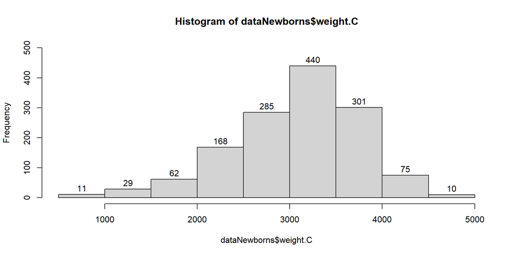

```r
hist(dataNewborns$weight.C,
     labels = TRUE, #popisky jednotlivych hodnot
     ylim = c(0, 500)) #urceni velikosti osy y - aby se nam tam ty popisky vesly
```

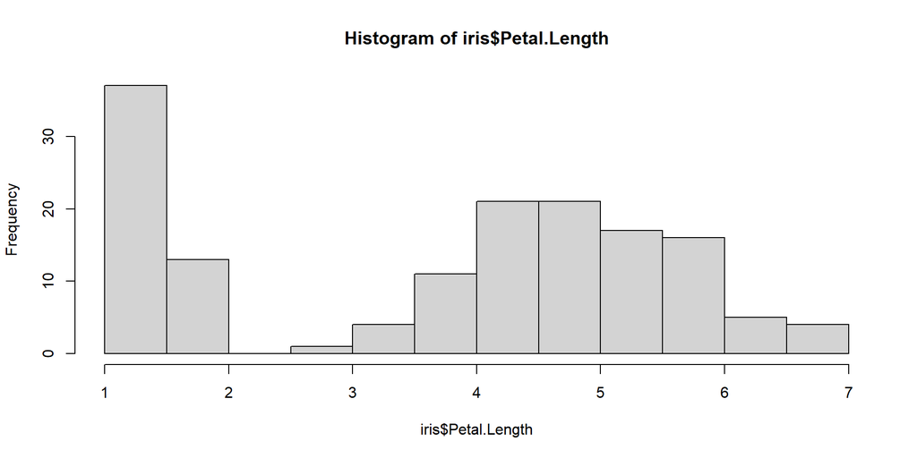

```r
hist(iris$Petal.Length)
```

Hm… proč je najednou víc těch třídících kontejnerů?

**Sturgesovo pravidlo počtu kontejnerů**

Jeden z nejvíce používaných způsobů výpočtu počtu kontejnerů je takzvané **Sturgesovo pravidlo**.

Funkce `hist` ho používá implicitně (argument `breaks = "Sturges"`), ale například u `ggplot` bude třeba si počet kontejnerů spočítat.

```r
#samotny vypocet
ceiling(1 + 3.3 * log10(length(iris$Petal.Length)))
```

```
[1] 9
```

```r
#existuje pro to ovsem fce
nclass.Sturges(iris$Petal.Length)
```

```
[1] 9
```

## Čárový graf (line chart)

> graf který zobrazuje vývoj specifické numerické hodnoty - obvykle používán pro časové řady, kdy osa x je kontinuální vývoj ukazující trendy

Dataset `Nile` obsahuje údaje o ročním průtoku vody v řece Nil v Egyptě v letech 1871-1970.

Po ukázce plotu si vysvětlíme, co jsou to **časové řady**.

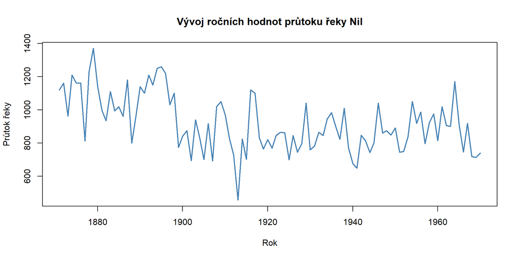

```r
plot(Nile,
  type = "l", #l - line chart
  col = "#4682b4", #hex kod barvy
  lwd = 2, #sirka cary
  xlab = "Rok",
  ylab = "Průtok řeky",
  main = "Vývoj ročních hodnot průtoku řeky Nil")
```

### Časové řady

> Časová řada je soubor hodnot určité proměnné, které jsou zaznamenávány postupně v čase.

**Jednoduše řečeno: sledujeme, jak se nějaká veličina mění v průběhu času.**

- jak se mění teplota během jednotlivých měsíců
- jak se mění počet narozených dětí v jednotlivých letech
- jak se mění cena akcií během jednotlivých dnů

```r
Nile
```

```
Time Series:
Start = 1871
End = 1970
Frequency = 1
  [1] 1120 1160  963 1210 1160 1160  813 1230 1370 1140  995  935 1110  994 1020
 [16]  960 1180  799  958 1140 1100 1210 1150 1250 1260 1220 1030 1100  774  840
 [31]  874  694  940  833  701  916  692 1020 1050  969  831  726  456  824  702
 [46] 1120 1100  832  764  821  768  845  864  862  698  845  744  796 1040  759
 [61]  781  865  845  944  984  897  822 1010  771  676  649  846  812  742  801
 [76] 1040  860  874  848  890  744  749  838 1050  918  986  797  923  975  815
 [91] 1020  906  901 1170  912  746  919  718  714  740
```

```r
str(Nile)
```

```
 Time-Series [1:100] from 1871 to 1970: 1120 1160 963 1210 1160 1160 813 1230 1370 1140 ...
```

## Procvičení - linechart

Dataset `UKgas` obsahuje čtvrtletní spotřebu plynu ve Velké Británii v letech 1960–1986.

**Zjisti, jak se vyvíjela spotřeba plynu.**

## Bodový graf (scatter plot)

> graf který zobrazuje vztah mezi dvěmi numerickými hodnotami, kdy každá hodnota je vyjádřena jedním bodem

Scatter plot jsme si defakto ukazovali již na začátku dnešní lekce - **jedná se o jeden z nejzákladnějších grafů v R**.

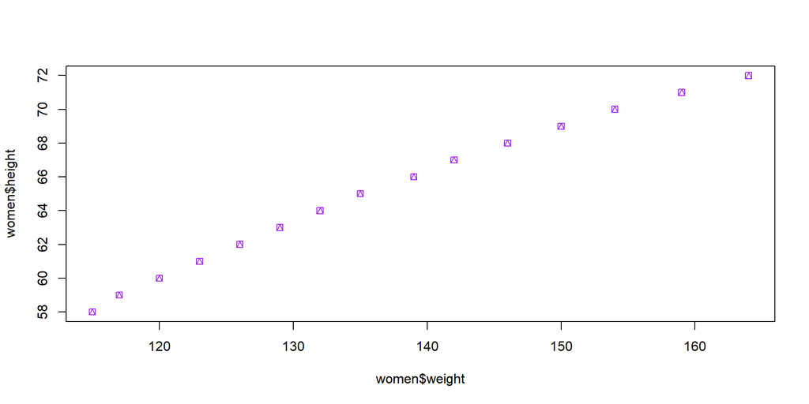

```r
plot(
  women$height ~ women$weight,
  type = "p", #p - point typ grafu
  pch = 14,
  col = "purple")
```

## Samostatné cvičení - baseR vizualizace

V datasetu `chickwts` máme přehled váhy jednotlivých kuřat v závisosti na jejich krmivu.

**Jak byla jednotlivá krmiva zastoupena?**

## Řešení - baseR vizualizace

V datasetu `chickwts` máme přehled váhy jednotlivých kuřat v závisosti na jejich krmivu. **Jak byla jednotlivá krmiva zastoupena?**

1. Zobrazíme si hlavičku a strukturu datasetu.

```r
head(chickwts)
```

```
  weight      feed
1    179 horsebean
2    160 horsebean
3    136 horsebean
4    227 horsebean
5    217 horsebean
6    168 horsebean
```

```r
str(chickwts)
```

```
'data.frame':   71 obs. of  2 variables:
 $ weight: num  179 160 136 227 217 168 108 124 143 140 ...
 $ feed  : Factor w/ 6 levels "casein","horsebean",..: 2 2 2 2 2 2 2 2 2 2 ...
```

2. Vidíme, že se jedná o kategoriální data, použijeme proto barplot.

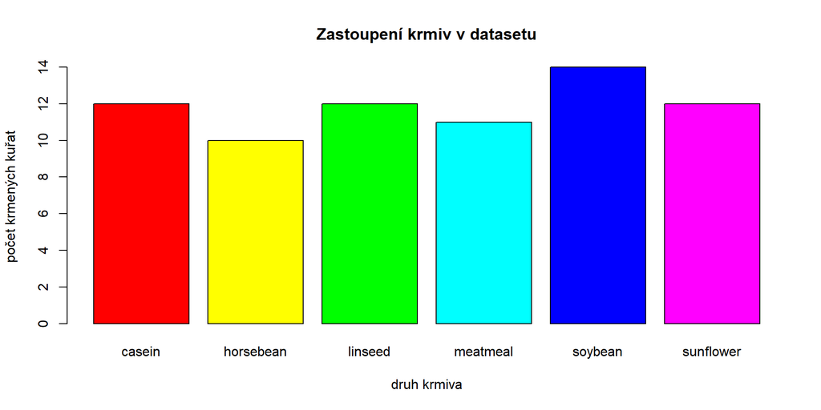

```r
barplot(table(chickwts$feed),
        xlab = "druh krmiva",
        ylab = "počet krmených kuřat",
        main = "Zastoupení krmiv v datasetu",
        col = rainbow(length(table(chickwts$feed))))
```

## Vizualizace pomocí balíčku `ggplot2`

V předchozí části jsme se seznámili s principy základních typů grafů a ukázali si, jak je vytvořit v baseR. Nyní se přesuneme k balíčku `ggplot2`.

### K čemu balíček slouží a čím se liší?

Pomocí `ggplot2` si můžeme vytvářet grafy na publikační úrovni. Oproti baseR máme i **mnohem širší možnosti personifikace vzhledu grafu** a ve výsledku i přehlednější syntax.

**Každý graf bude pouze tak dobrý jako podkladová data**

Je extrémně důležité, abyste přemýšleli nejenom nad tím, jestli můžete daný graf používat na vašich datech, ale abyste **prováděli důslednou kontrolu a případnou úpravu dat, které budete vizualizovat**.

Jsou všechna kategorická data faktory? Pokud je to relevantní, odstranili jste `NA` hodnoty?

## `ggplot` syntax

Samotná vizualizace se pak provádí pomocí funkce `ggplot`. V této sekci si probereme základní syntax, ze kterého vychází všechny následující vizualizace.

**Jednotlivé vstvy a funkce se spojují dohromady symbolem `+`.**

### Barplot v `ggplot`

Vytvořme si základní barplot, na kterém si prakticky ukážeme syntax a korespondující `geom_*` vrstvu.

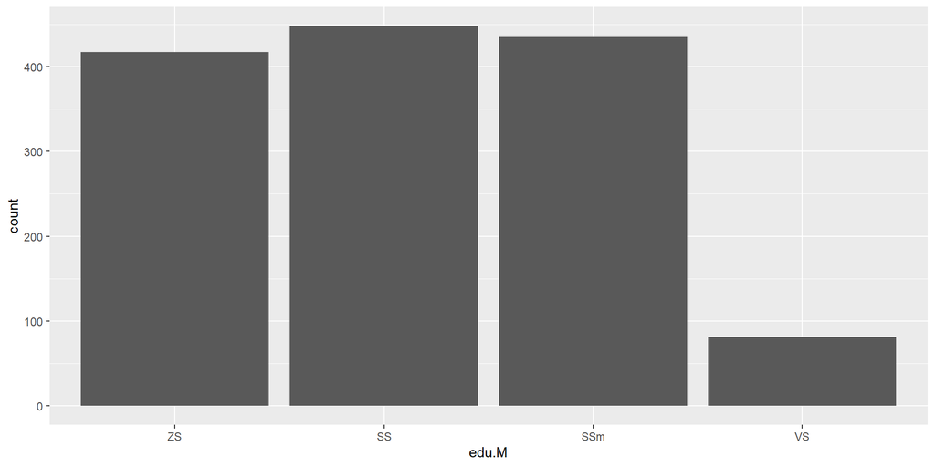

```r
ggplot(data = dataNewborns, #mapujeme dataNeborns
  aes(x = edu.M)) + #osa x maji byt hodnoty z edu.M
  geom_bar() #chceme barplot
```

### Histogram v `ggplot`

Jakým způsobem si vytvoříme základní histogram? Zobrazme si histogram ukazující distribuci váhy novorozenců.

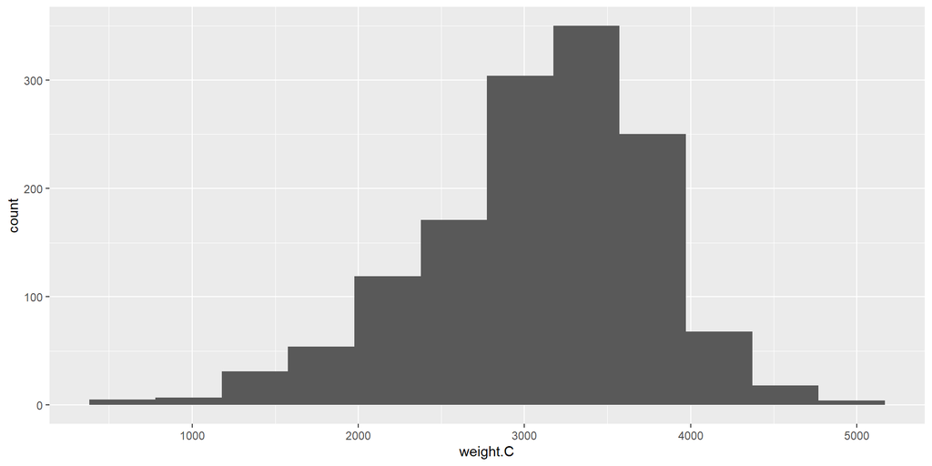

```r
ggplot(dataNewborns,
  aes(x = weight.C)) +
  #vyzkousejte si co by se stalo bez argumentu bins
  geom_histogram(bins = nclass.Sturges(dataNewborns$weight.C))
```

## Čárový graf v `ggplot`

Narozdíl od baseR, v `ggplot` je tvorba line chartu o něco složitější - `ggplot` **vyžaduje jasně definované hodnoty x/y**.

Musíme proto dle těchto potřeb data upravit.

```r
Nile_df <- data.frame(
  year = as.numeric(time(Nile)),
  flow = as.numeric(Nile))
head(Nile_df)
```

```
  year flow
1 1871 1120
2 1872 1160
3 1873  963
4 1874 1210
5 1875 1160
6 1876 1160
```

Nyní můžeme přejít k samotné vizualizaci.

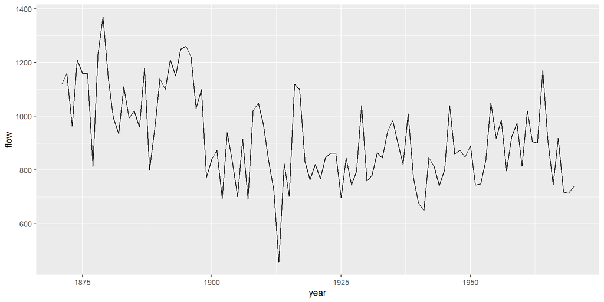

```r
ggplot(Nile_df, aes(x = year, y = flow)) +
  geom_line()
```

## Bodový graf v `ggplot`

Přestože baseR umožňuje rychlou tvorbu tohoto typu grafu, byla by škoda neukázat si možnosti jeho vytvoření v `ggplot` a to nejenom kvůli možnosti rozdělování do skupin, jak si ukážeme v následující sekci.

Vytvořme si graf závislosti šířky a délky okvětního kalichu v datatsetu `iris`.

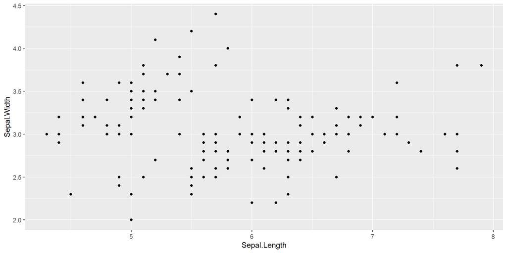

```r
ggplot(iris, aes(x = Sepal.Length, y = Sepal.Width)) +
    geom_point() #bodovy graf
```

A… to je všechno? Vždyť to ani nevypadá nijak hezky?

Jak bylo řečeno, `ggplot` umožňuje nepřeberné množství úprav grafu.

**Zkusme si proto třeba na barplotu ukázat, jaké veškeré kulišárny lze s tímto balíčkem provádět.**

### Barvy a tvary (nejen) kontejneru

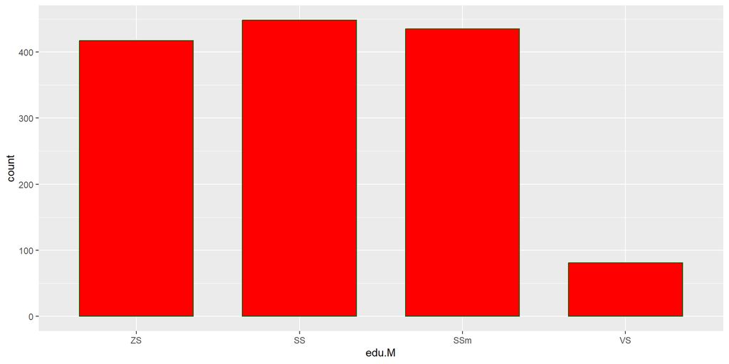

```r
ggplot(data = dataNewborns,
       aes(x = edu.M)) +
  geom_bar(fill = "red", #jakou chceme barvu kontejneru
           colour = "darkgreen", #jaky maji mit obrys
           width = 0.7) #a jak maji byt siroke?
```

### Popisky

Všimněte si **přidání nových vrstev `geom_text()` a `labs()`**!

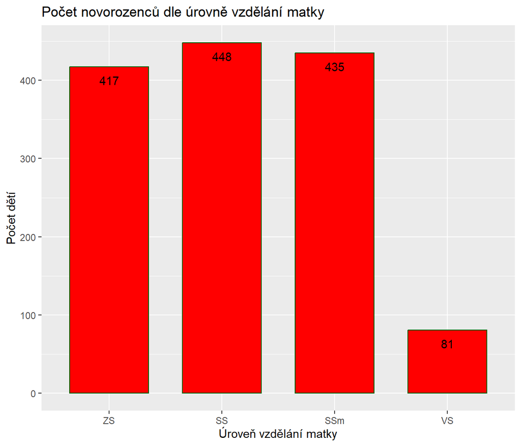

```r
ggplot(data = dataNewborns,
       aes(x = edu.M)) +
  geom_bar(fill = "red",
           colour = "darkgreen",
           width = 0.7) +
  #vypis hodnoty z osy y (soucet aka count) - podivejte se na puvodni popisek osy y
  geom_text(stat = "count",
            aes(label = after_stat(count)), #namapuj to jako popisek kontejneru
            size = 4, #velikost textu
            vjust = 2) + #umisti popisky ve vzdalenosti 2 od okraje
  labs(title = "Počet novorozenců dle úrovně vzdělání matky", #jaky ma byt nadpis
       x = "Úroveň vzdělání matky", #popis osy x
       y = "Počet dětí") #popis osy y
```

### Změna pozadí

Je možné upravit si i pozadí a celkový vizuál podkladu grafu.

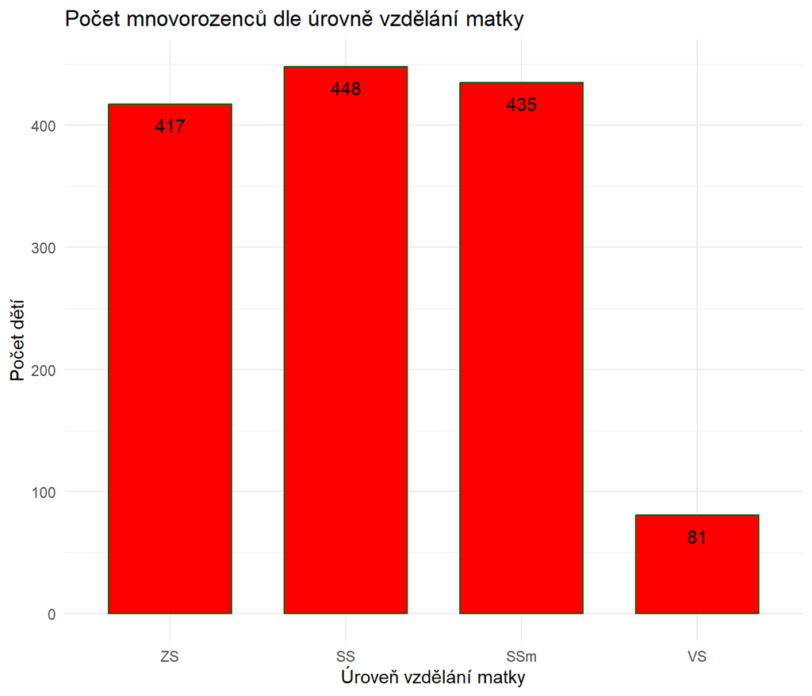

```r
ggplot(data = dataNewborns,
       aes(x = edu.M)) +
  geom_bar(fill = "red",
           colour = "darkgreen",
           width = 0.7) +
  geom_text(stat = "count",
            aes(label = after_stat(count)),
            vjust = 2) +
  labs(title = "Počet mnovorozenců dle úrovně vzdělání matky",
       x = "Úroveň vzdělání matky",
       y = "Počet dětí") +
  theme_minimal() #chci tento typ vizualu
```

### Rozdělení podle kategorii

Co kdybychom chtěli mít hodnoty rozdělené nejenom podle jedné ale i dle více kategorií?

**Rozdělení podle levels faktorů**

Při rozdělování je třeba, aby R dokázalo hodnoty brát jako samostatné kategorie - **dané hodnoty musí být faktor!**

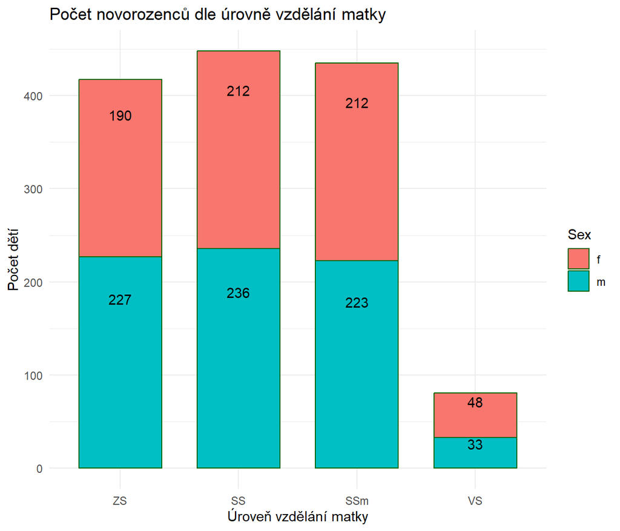

```r
ggplot(data = dataNewborns,
       aes(x = edu.M,
           fill = sex.C)) + #rozdel kontejnery dle pohlavi
  geom_bar(colour = "darkgreen",
           width = 0.7) +
  geom_text(stat = "count",
            aes(label = after_stat(count)),
            #musime si upravit pozici popisku
            position = position_stack(vjust = 0.8)) +
  labs(title = "Počet novorozenců dle úrovně vzdělání matky",
       x = "Úroveň vzdělání matky",
       y = "Počet dětí",
       fill = "Sex") + #popisek legendy
  theme_minimal()
```

Co když ale **kategorie chceme mít vedle sebe**?

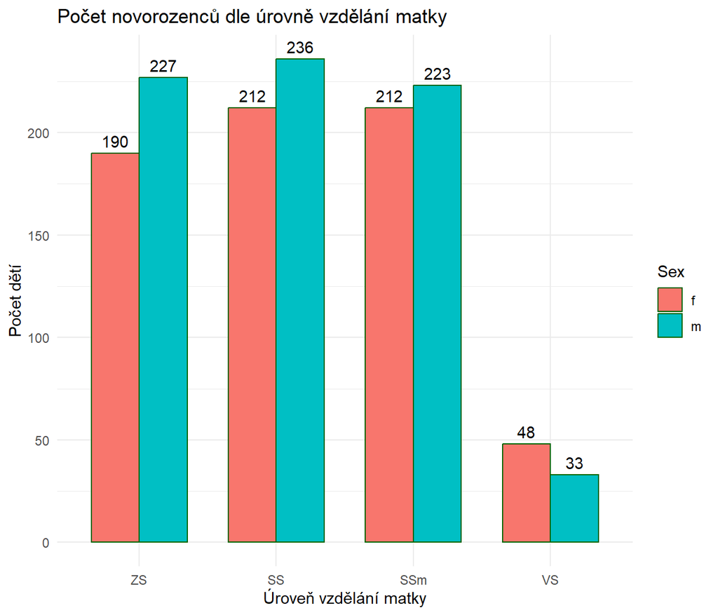

```r
ggplot(data = dataNewborns,
       aes(x = edu.M,
           fill = sex.C)) +
  geom_bar(colour = "darkgreen",
           width = 0.7,
           position = "dodge") + #popisky vedle sebe
  geom_text(stat = "count",
            aes(label = after_stat(count)),
            #jak se maji vedle sebe popisky poskladat
            position = position_dodge(width = 0.7),
            vjust = -0.5) +
  labs(title = "Počet novorozenců dle úrovně vzdělání matky",
       x = "Úroveň vzdělání matky",
       y = "Počet dětí",
       fill = "Sex") +
  theme_minimal()
```

## Samostatné cvičení - barplot

Z hodnot v datasetu `dataNewborns` pomocí funkcí z balíčku `ggplot2` vtvořte graf, který bude znázorňovat rozdělení novorozenců podle počtu jejich starších sourozenců (`prch.N`). Rozdělte novorozence dle pohlaví (`sex.C`).

Nejdříve si vytvořte jednoduchý holý graf, abyste zjistili, že vám kód běží - **až později si do něj přidávejte další funkce a vylepšení**.

Pohrajte si s barvami, velikostmi, pozadím… nebojte se googlit :].

## Řešení - barplot

**Z hodnot v datasetu `dataNewborns` pomocí funkcí z balíčku `ggplot2` vtvořte graf, který bude znázorňovat rozdělení novorozenců podle počtu jejich starších sourozenců (`prch.N`). Rozdělte novorozence dle pohlaví (`sex.C`).**

1. Podívejme se na to, s jakými daty pracujeme

```r
str(dataNewborns)
```

```
'data.frame':   1381 obs. of  4 variables:
 $ edu.M   : Factor w/ 4 levels "ZS","SS","SSm",..: 2 2 2 1 3 2 1 2 2 1 ...
 $ prch.N  : int  0 0 0 0 0 1 2 0 0 0 ...
 $ sex.C   : Factor w/ 2 levels "f","m": 2 2 1 2 2 2 1 1 1 2 ...
 $ weight.C: int  3470 3240 2980 3280 3030 3650 4080 3040 3070 3110 ...
 - attr(*, "na.action")= 'omit' Named int [1:21] 53 54 256 297 476 482 682 708 760 857 ...
  ..- attr(*, "names")= chr [1:21] "53" "54" "256" "297" ...
```

2. Hodnoty ve sloupci `prch.N` jsou numerické, je třeba je změnit na faktory.

```r
dataNewborns$prch.N <- as.factor(dataNewborns$prch.N)
```

3. Následně již můžeme vytvořit graf - zde je jedna z možných variant.

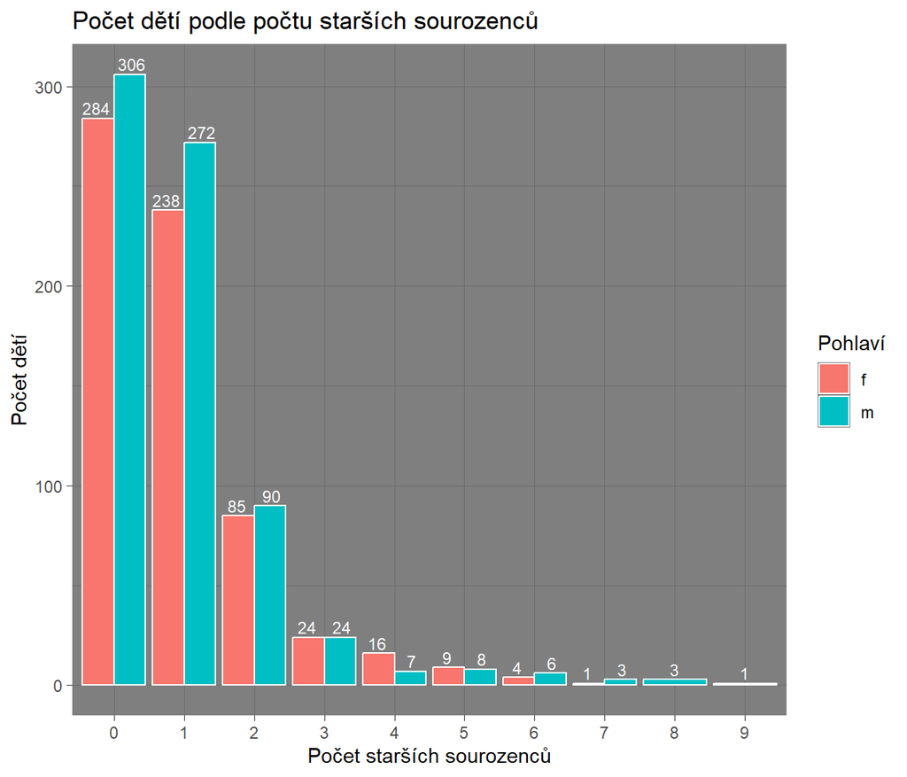

```r
ggplot(dataNewborns, aes(x = prch.N, fill = sex.C)) +
  geom_bar(
    position = "dodge",
    color = "white") +
  geom_text(
    stat = "count",
    aes(label = after_stat(count)),
    position = position_dodge(width = 1),
    vjust = -0.3,
    colour = "white", #barva textu
    size = 3) + #velikost textu
  labs(
    title = "Počet dětí podle počtu starších sourozenců",
    x = "Počet starších sourozenců",
    y = "Počet dětí",
    fill = "Pohlaví") +
  theme_dark()
```

Existuje samozřejmě i mnoho dalších argumentů a `ggplot2` funkcí.

**Bohužel, jediným způsobem, jakým se naučíte všechny ty funkce, které by se vám hodili nejvíc je, že si sami funkce budete opakovaně zkoušet.**

Během dneška (a ani zítřka, či pozítří) bychom si všechny funkce projít nestihli, proto dostanete na Kde hledat dál odkazy na několik stránek, které vám mohou sloužit jako skvělý start pro vaše další sebevzdělávání.

**A v mezičase si ukážeme pár funkcí a argumentů, co lze použít u histogramu.**

### Linie statistických hodnot

Přes histogram (a i jiné grafy) si **můžeme namapovat linie určující statistické hodnoty**.

Zde si ukážeme vytvoření linie, která bude určovat průměr hodnot.

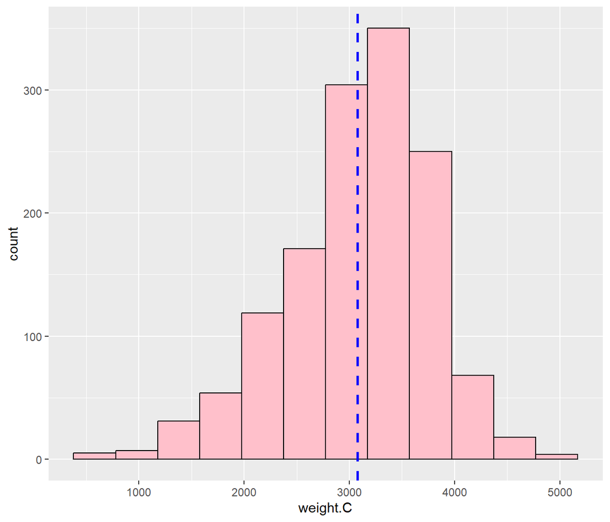

```r
ggplot(data = dataNewborns) +
  aes(x = weight.C) +
  geom_histogram(bins = nclass.Sturges(dataNewborns$weight.C),
                 color = "black",
                 fill = "pink") +
  #urci prumer a namapuj ho na osu x
  geom_vline(aes(xintercept = mean(weight.C)),
             color = "blue",
             linetype = "dashed", #typ linie
             linewidth = 1) #sirka linie
```

### Překrývaní se grafů a průhlednost

Při rozdělování histogramu podle kategorií se nám může stát, že **grafy se budou navzájem překrývat.** V takovém příadě se hodí udělat je částečně průhlednými.

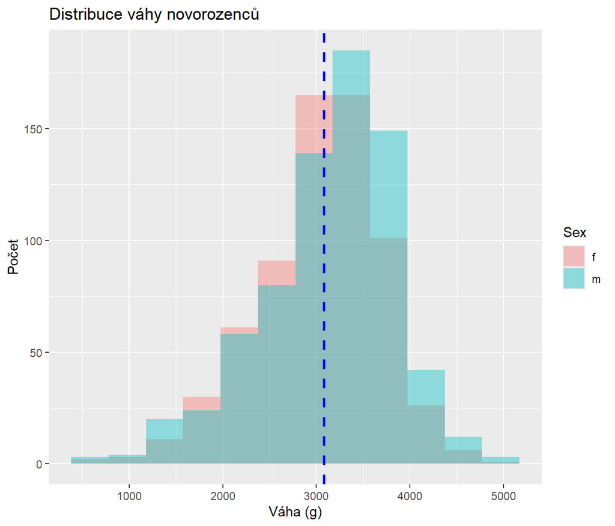

```r
ggplot(data = dataNewborns) +
  aes(x = weight.C,
      fill = sex.C) + #rozdel podle pohlavi
  geom_histogram(bins = nclass.Sturges(dataNewborns$weight.C),
                 alpha = 0.4, #pruhlednost 40 %
                 position = "identity") + #prekryj grafy pres sebe
  geom_vline(aes(xintercept = mean(weight.C)),
             color = "blue",
             linetype = "dashed",
             linewidth = 1) +
  labs(title="Distribuce váhy novorozenců",
       x = "Váha (g)",
       y = "Počet",
       fill = "Sex")
```

## Linie statistických hodnot pro každou kategorii

Nejdříve si **musíme vytvořit hodnoty (v tomto případě průměry), které mají být namapovány**.

```r
meanWeightSex <- dataNewborns %>%
  group_by(sex.C) %>%
  summarise(mean_weight = mean(weight.C)); meanWeightSex
```

```
# A tibble: 2 × 2
  sex.C mean_weight
  <fct>       <dbl>
1 f           3022.
2 m           3129.
```

Následně je můžeme použít v grafu.

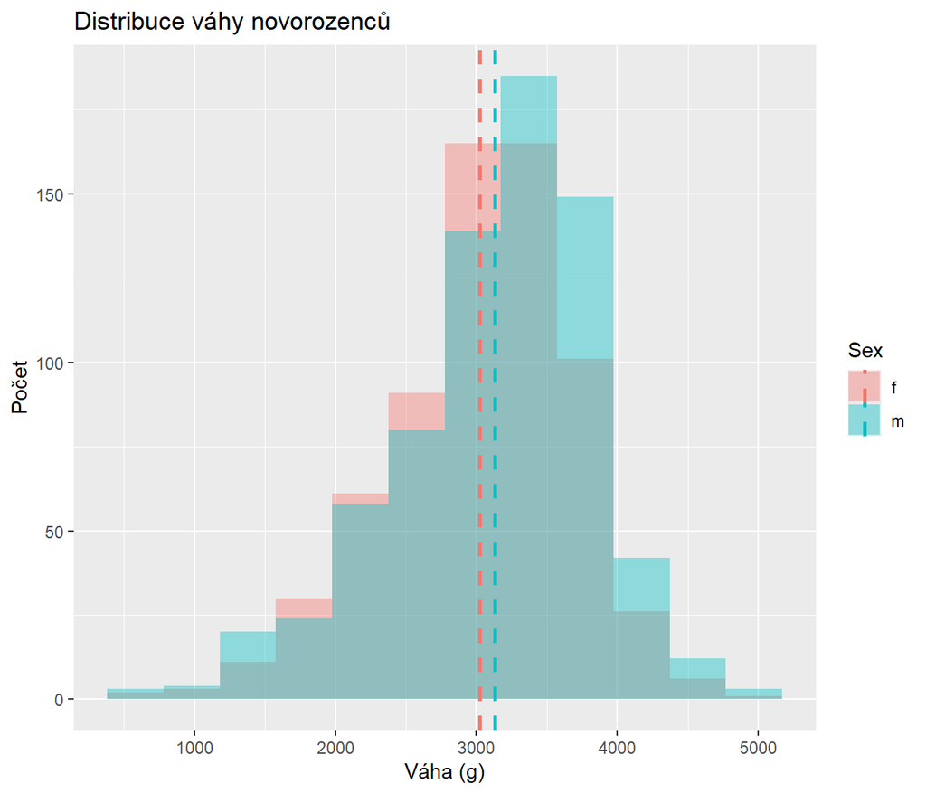

```r
ggplot(data = dataNewborns) +
  aes(x = weight.C,
      fill = sex.C) +
  geom_histogram(bins = nclass.Sturges(dataNewborns$weight.C),
                 alpha = 0.4,
                 position = "identity") +
  geom_vline(data = meanWeightSex, #namapuj udaje z meanWeightSex
             aes(xintercept = mean_weight, #pouzij data z tohoto sloupce
                 colour = sex.C), #delime grafy podle pohlavi tak at sedi barvy
             linetype = "dashed",
             linewidth = 1) +
  labs(title="Distribuce váhy novorozenců",
       x = "Váha (g)",
       y = "Počet",
       fill = "Sex",
       color = "Sex") #pridani car do legendy
```

### Rozdělení jednotlivých kategorií do individuálních grafů

Co když ale chceme, aby **každá kategorie měla vlastní graf**?

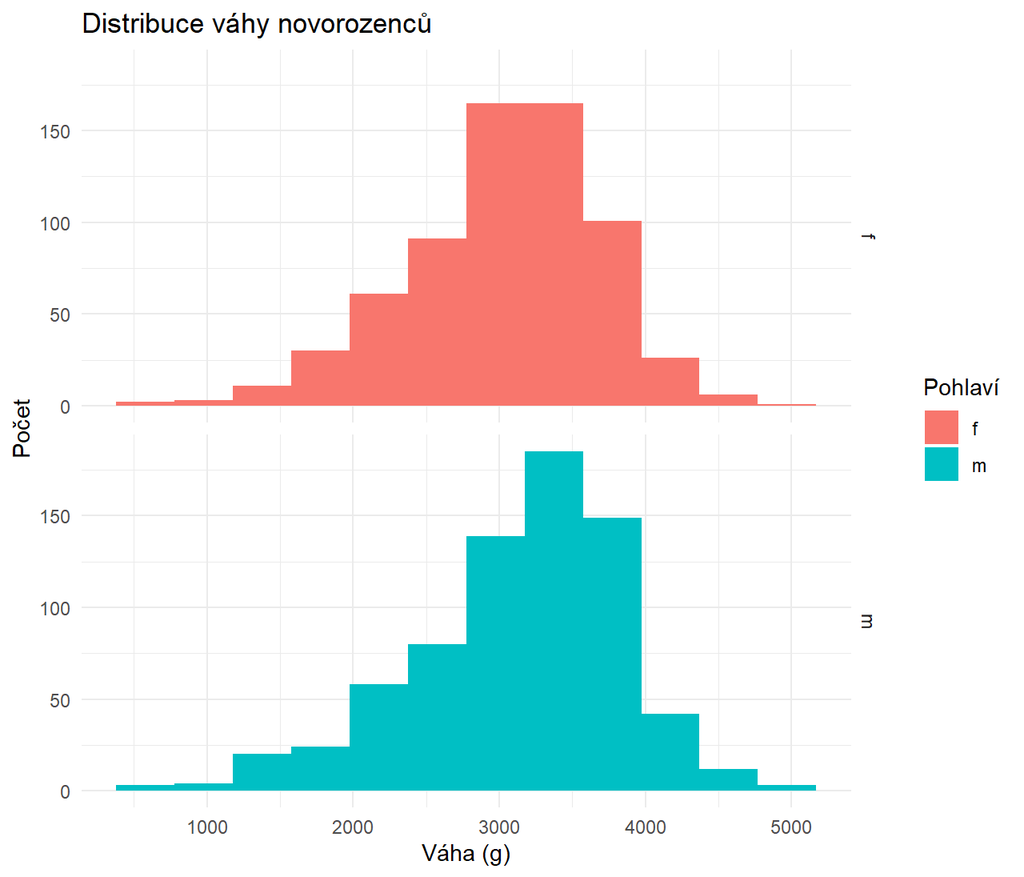

```r
ggplot(data = dataNewborns,
       aes(x = weight.C, fill = sex.C)) +
  geom_histogram(
    bins = nclass.Sturges(dataNewborns$weight.C)) +
  facet_grid(sex.C ~ ., #rozdel do individualnich grafu dle levels sex.C
             scales = "free") + #kazdy graf muze mit jine xlim a ylim
  labs(
    title = "Distribuce váhy novorozenců",
    x = "Váha (g)",
    y = "Počet",
    fill = "Pohlaví") +
  theme_minimal()
```

### Upravení barev

Argument `fill` určuje barvy automaticky. **Co když si ale chceme barvy kategorií vybrat?**

[figure not shown]

```r
ggplot(data = dataNewborns,
       aes(x = weight.C, fill = sex.C)) +
  geom_histogram(
    bins = nclass.Sturges(dataNewborns$weight.C)) +
  #nastaveni specifickych barev pro fill
  scale_fill_manual(values = c("m" = "pink", "f" = "lightgreen")) +
  labs(
    title = "Distribuce váhy novorozenců",
    x = "Váha (g)",
    y = "Počet",
    fill = "Pohlaví") +
  theme_minimal()
```

## Kde hledat dál

[The R Graph Gallery](https://r-graph-gallery.com/)

Jeden z nejlepších a nejpčehlednějších webů s ukázkou tvorby snad každého typu grafu.

[R Graphics Cookbook](https://r-graphics.org/)

Učebnice, která do podrobna rozebírá možnosti vizualizace dat. Pracuje především s `ggplot2`.

[R Color Palettes: The Complete Reference](https://www.datanovia.com/blog/r-color-palettes)

Seznámení se s barevnými paletami v R a jejich podrobný přehled.

## Domácí úkol

1. Z datasetu `datanewborns` zjistěte a zobrazte průměrnou váhu novorozence v závislosti na jeho pohlaví a počtu starších sourozenců.
2. Máme dataset `diamonds` v R, která v sobě obsahuje informace o typu a hodnotě jednotlivých diamantů. Pomocí grafu ukaž, jaká je distribuce ceny (`price`) na základě kvality zpracování (`cut`).

Skript s výpočtem zašlete nejpozději do pátku před příští hodinou na lucie.hoskova@ruk.cuni.cz